# Predicting exercise moves

@martinvanelp

22 november 2015

The goal of this project is to predict the manner in which 6 participants performed barbell lifts. The did this correctly and incorrectly in 5 different ways. For this prediction data from accelerometers on the belt, forearm, arm, and dumbell of the 6 participants is used.

# Model description

The dataset contains many different variables and the eventual goal is to classify the ways in which barbell lifts were performed. This means that an algorithm that is intended for classifying is chosen. In the analysis two algorithms from the caret package were tried: rpart and rf (random forest).

## Data cleaning

After exploring the data several columns were dropped that neither contained the classe-variable or the predictors. Then upon further investigation, from these predictor variables more columns were dropped when they contained little or no values.

## Validation set

30% of the training set is set aside as a validation set to determine the out of sample error later.

## Rpart

The plot of the Rpart tree shows that classe A and E are predicted rather well. It also shows that the model has trouble classifying the other classes.

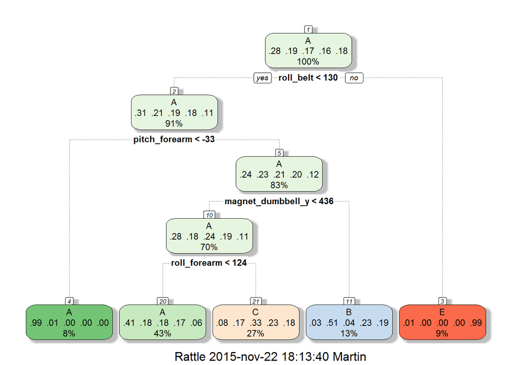

The confusion matrix beneath confirms the impression that the Rpart model is only good for two classes. The total accuracy, even within the training set, is rather low, classes B and C get classified wrongly often, and classe D is never predicted.

```
## Confusion Matrix and Statistics
##
##           Reference
## Prediction    A    B    C    D    E
##          A 3545 1096 1093  989  353
##          B   60  923   78  416  350
##          C  291  639 1225  847  658
##          D    0    0    0    0    0
##          E   10    0    0    0 1164
##
## Overall Statistics
##
##                Accuracy : 0.4992
##                  95% CI : (0.4908, 0.5076)
##     No Information Rate : 0.2843
##     P-Value [Acc > NIR] : < 2.2e-16
##
##                   Kappa : 0.3458
##  Mcnemar's Test P-Value : NA
##
## Statistics by Class:
##
##                      Class: A Class: B Class: C Class: D Class: E
## Sensitivity            0.9076  0.34725  0.51127   0.0000  0.46099
## Specificity            0.6408  0.91840  0.78529   1.0000  0.99911
## Pos Pred Value         0.5010  0.50520  0.33470      NaN  0.99148
## Neg Pred Value         0.9458  0.85432  0.88379   0.8361  0.89167
## Prevalence             0.2843  0.19349  0.17442   0.1639  0.18381
## Detection Rate         0.2581  0.06719  0.08918   0.0000  0.08473
## Detection Prevalence   0.5151  0.13300  0.26643   0.0000  0.08546
## Balanced Accuracy      0.7742  0.63283  0.64828   0.5000  0.73005
```

## Random forest

When the random forest algorithm is applied the results are clearly better. Most activities get classified correctly as the output of the final model beneath shows. The estimated error rate is about 8%.

```
##
## Call:
##  randomForest(x = x, y = y, mtry = param$mtry, proximity = TRUE)
##                Type of random forest: classification
##                      Number of trees: 500
## No. of variables tried at each split: 27
##
##         OOB estimate of  error rate: 8.43%
## Confusion matrix:
##     A   B   C   D   E class.error
## A 381   5   0   5   0  0.02557545
## B  21 222  14   2   7  0.16541353
## C   2  14 217   5   2  0.09583333
## D   5   3  13 199   6  0.11946903
## E   0   2   5   5 241  0.04743083
```

The caveat with the random forest algorithm is slow processing time. Which is why in training the model only 1376 randomly chosen observations were used. This is 10% of the remaining data set, after setting aside the validation set.

## Choice of model

The random forest algorithm has far better results, when it comes to predicting the right classe in the training set. It is therefore selected as the model to cross validate, although a random forest is hard to interpret.

# Cross validation

The random forest is applied to the validation set that was set aside earlier, to find the expected out of sample error. The accuracy is basicly close to the estimated error rate before. Moreover, the Kappa statistic is higher than 0.80 which means the classifier is almost perfect, see [Wikipedia](https://en.wikipedia.org/wiki/Cohen%27s_kappa).

```
## Confusion Matrix and Statistics
##
##           Reference
## Prediction    A    B    C    D    E
##          A 1624   78    3   22    1
##          B   17  995   42    9   16
##          C   11   46  952   29   27
##          D   10   13   18  892   13
##          E   12    7   11   12 1025
##
## Overall Statistics
##
##                Accuracy : 0.9325
##                  95% CI : (0.9258, 0.9388)
##     No Information Rate : 0.2845
##     P-Value [Acc > NIR] : < 2.2e-16
##
##                   Kappa : 0.9146
##  Mcnemar's Test P-Value : 2.453e-11
##
## Statistics by Class:
##
##                      Class: A Class: B Class: C Class: D Class: E
## Sensitivity            0.9701   0.8736   0.9279   0.9253   0.9473
## Specificity            0.9753   0.9823   0.9767   0.9890   0.9913
## Pos Pred Value         0.9398   0.9222   0.8939   0.9429   0.9606
## Neg Pred Value         0.9880   0.9700   0.9846   0.9854   0.9882
## Prevalence             0.2845   0.1935   0.1743   0.1638   0.1839
## Detection Rate         0.2760   0.1691   0.1618   0.1516   0.1742
## Detection Prevalence   0.2936   0.1833   0.1810   0.1607   0.1813
## Balanced Accuracy      0.9727   0.9279   0.9523   0.9572   0.9693
```